# Analysis of Goodreads data on Kaggle

Hoang Anh NGO

true

# Loading libraries and understanding the basics of this dataset

## Loading libraries

First, we will load all the necessary libraries for this notebook.

```r
library(ggplot2)
library(dplyr)
library(RColorBrewer)
library(viridis)
library(WVPlots)
library(naniar)
library(e1071)
library(plotrix)
library(ggcorrplot)
library(waffle)
library(extrafont)
library(GGally)
library(tidyverse)
library(cluster)
library(factoextra)
```

## Understanding the basic structure of the dataset

We import and investigate the structure of the dataset.

```r
goodreads <- read.csv('/Users/ngohoanganh/Desktop/Goodreads Kaggle project/books.csv', stringsAsFactors = FALSE)
str(goodreads)
```

```
'data.frame':   13724 obs. of  10 variables:
 $ bookID            : int  1 2 3 4 5 8 9 10 12 13 ...
 $ title             : chr  "Harry Potter and the Half-Blood Prince (Harry Potter  #6)" "Harry Potter and the Order of the Phoenix (Harry Potter  #5)" "Harry Potter and the Sorcerer's Stone (Harry Potter  #1)" "Harry Potter and the Chamber of Secrets (Harry Potter  #2)" ...
 $ authors           : chr  "J.K. Rowling-Mary GrandPré" "J.K. Rowling-Mary GrandPré" "J.K. Rowling-Mary GrandPré" "J.K. Rowling" ...
 $ average_rating    : chr  "4.56" "4.49" "4.47" "4.41" ...
 $ isbn              : chr  "0439785960" "0439358078" "0439554934" "0439554896" ...
 $ isbn13            : chr  "9780439785969" "9780439358071" "9780439554930" "9780439554893" ...
 $ language_code     : chr  "eng" "eng" "eng" "eng" ...
 $ X..num_pages      : chr  "652" "870" "320" "352" ...
 $ ratings_count     : int  1944099 1996446 5629932 6267 2149872 38872 18 27410 3602 240189 ...
 $ text_reviews_count: int  26249 27613 70390 272 33964 154 1 820 258 3954 ...
```

```r
head(goodreads)
```

|  | bookID | title | authors | average_rating | isbn | isbn13 | language_code | X..num_pages | ratings_count | text_reviews_count |
| --- | --- | --- | --- | --- | --- | --- | --- | --- | --- | --- |
| 1 | 1 | Harry Potter and the Half-Blood Prince (Harry Potter #6) | J.K. Rowling-Mary GrandPré | 4.56 | 0439785960 | 9780439785969 | eng | 652 | 1944099 | 26249 |
| 2 | 2 | Harry Potter and the Order of the Phoenix (Harry Potter #5) | J.K. Rowling-Mary GrandPré | 4.49 | 0439358078 | 9780439358071 | eng | 870 | 1996446 | 27613 |
| 3 | 3 | Harry Potter and the Sorcerer's Stone (Harry Potter #1) | J.K. Rowling-Mary GrandPré | 4.47 | 0439554934 | 9780439554930 | eng | 320 | 5629932 | 70390 |
| 4 | 4 | Harry Potter and the Chamber of Secrets (Harry Potter #2) | J.K. Rowling | 4.41 | 0439554896 | 9780439554893 | eng | 352 | 6267 | 272 |
| 5 | 5 | Harry Potter and the Prisoner of Azkaban (Harry Potter #3) | J.K. Rowling-Mary GrandPré | 4.55 | 043965548X | 9780439655484 | eng | 435 | 2149872 | 33964 |
| 6 | 8 | Harry Potter Boxed Set Books 1-5 (Harry Potter #1-5) | J.K. Rowling-Mary GrandPré | 4.78 | 0439682584 | 9780439682589 | eng | 2690 | 38872 | 154 |

```r
print(paste('The original goodreads book dataset has',nrow(goodreads),'rows and',ncol(goodreads),'columns.'))
```

```
[1] "The original goodreads book dataset has 13724 rows and 10 columns."
```

## Fixing problems of the dataset

First of all, we know that this dataset has 13724 observations with 10 variables. There is one variable that is supposed to be written as “# num_pages”. However, as R cannot read special characters in column names, for the sake of convenience, we rename this variable as “num_pages”.

We obverse some problems with this dataset. At columns 4 and 8 (corresponding to variables “average_rating” and “num_page”), we can see that the observations are of type “character”, while they should be of type “integer”. We fix the problem with the function as.numeric in the following code chunk.

However, while fixing the problem above, those two columns yield some NA values. This can be due to those rows having too many commas, forcing the values that should belong to one columns move to another column. We omit these outliers for a clean dataset by using the function na.omit.

Moreover, one of the famous authors that we know, J.K Rowling, has a fairly long name of “J.K Rowling-Mary GrandPré”. After changing the author’s name, we have the dataset available for further analysis.

```r
goodreads[goodreads=='J.K. Rowling-Mary GrandPré'] <- 'J.K. Rowling'
head(goodreads)
```

|  | bookID | title | authors | average_rating | isbn | isbn13 | language_code | X..num_pages | ratings_count | text_reviews_count |
| --- | --- | --- | --- | --- | --- | --- | --- | --- | --- | --- |
| 1 | 1 | Harry Potter and the Half-Blood Prince (Harry Potter #6) | J.K. Rowling | 4.56 | 0439785960 | 9780439785969 | eng | 652 | 1944099 | 26249 |
| 2 | 2 | Harry Potter and the Order of the Phoenix (Harry Potter #5) | J.K. Rowling | 4.49 | 0439358078 | 9780439358071 | eng | 870 | 1996446 | 27613 |
| 3 | 3 | Harry Potter and the Sorcerer's Stone (Harry Potter #1) | J.K. Rowling | 4.47 | 0439554934 | 9780439554930 | eng | 320 | 5629932 | 70390 |
| 4 | 4 | Harry Potter and the Chamber of Secrets (Harry Potter #2) | J.K. Rowling | 4.41 | 0439554896 | 9780439554893 | eng | 352 | 6267 | 272 |
| 5 | 5 | Harry Potter and the Prisoner of Azkaban (Harry Potter #3) | J.K. Rowling | 4.55 | 043965548X | 9780439655484 | eng | 435 | 2149872 | 33964 |
| 6 | 8 | Harry Potter Boxed Set Books 1-5 (Harry Potter #1-5) | J.K. Rowling | 4.78 | 0439682584 | 9780439682589 | eng | 2690 | 38872 | 154 |

```r
for(i in c(4,8)) {
  goodreads[,i] <- as.numeric(goodreads[,i])
}
```

```
NAs introduced by coercionNAs introduced by coercion
```

```r
names(goodreads)[names(goodreads) == "X..num_pages"] <- "num_pages"
goodreads <- na.omit(goodreads)
str(goodreads)
```

```
'data.frame':   13714 obs. of  10 variables:
 $ bookID            : int  1 2 3 4 5 8 9 10 12 13 ...
 $ title             : chr  "Harry Potter and the Half-Blood Prince (Harry Potter  #6)" "Harry Potter and the Order of the Phoenix (Harry Potter  #5)" "Harry Potter and the Sorcerer's Stone (Harry Potter  #1)" "Harry Potter and the Chamber of Secrets (Harry Potter  #2)" ...
 $ authors           : chr  "J.K. Rowling" "J.K. Rowling" "J.K. Rowling" "J.K. Rowling" ...
 $ average_rating    : num  4.56 4.49 4.47 4.41 4.55 4.78 3.69 4.73 4.38 4.38 ...
 $ isbn              : chr  "0439785960" "0439358078" "0439554934" "0439554896" ...
 $ isbn13            : chr  "9780439785969" "9780439358071" "9780439554930" "9780439554893" ...
 $ language_code     : chr  "eng" "eng" "eng" "eng" ...
 $ num_pages         : num  652 870 320 352 435 ...
 $ ratings_count     : int  1944099 1996446 5629932 6267 2149872 38872 18 27410 3602 240189 ...
 $ text_reviews_count: int  26249 27613 70390 272 33964 154 1 820 258 3954 ...
 - attr(*, "na.action")= 'omit' Named int  4011 4012 5688 5689 7057 7058 10603 10604 10671 10672
  ..- attr(*, "names")= chr  "4011" "4012" "5688" "5689" ...
```

```r
print(paste('The final goodreads book dataset has',nrow(goodreads),'rows and',ncol(goodreads),'columns.'))
```

```
[1] "The final goodreads book dataset has 13714 rows and 10 columns."
```

After fixing all the errors appeared in the dataset, we start to define the variables’ names. Their description is as follow: - **bookID**: the unique ID for each book/series - **title**: the title of each book/series - **authors**: the author(s) of the particular book/series - **average_rating**: the average ratings of the particular book/series, given by Goodreads’ users - **ISBN**: old ISBN number of 10 digits, including information about a book/series, for example name, author(s), publisher, genre, etc. - **ISBN13**: new ISBN number of 13 digits, introduced in 2007 - **Language_code**: 3-character language code, which indicates the language in which the book is written - **Num_page**: number of pages of each book/series - **Ratings_count**: number of ratings given by users for each book/series - **Text_reviews_count**: number of text reviews (apart from point reviews of scale 5) given by users for each book/series

## Missingness of data

We investigate whether there is any data cell missing with the vis_miss plot. Since we do not plot any significant in the plot, and it shows that less than 0.1% of the data is missing, we use gg_miss_var to get the exact number of data cells missing in each column. The result is, surprisingly, there is no data misising.

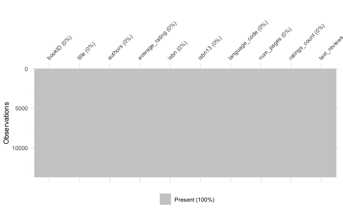

```r
vis_miss(goodreads)
```

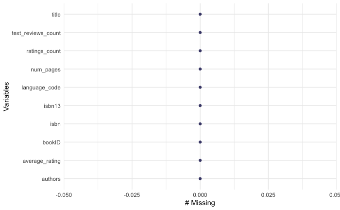

```r
gg_miss_var(goodreads)
```

# Exploratory Data Analysis (EDA) of the dataset Goodreads

In this part, we will answer some of the interesting exploratory questions by visualizing data.

## Correlation between numerical columns

First, we will see the correlation between numerical columns of this dataset by using Pearson’s R, Kendall rank and Spearman correlation coefficient. - Pearson’s R correlation coefficient is used to examine the strength and direction of the linear relationship between two continuous variables. - Kendall rank correlation coefficient (or Kendall tau’s coefficient) is a statistic used to measure the ordinal association between two measured quantities. - Spearman’s rank correlation coefficient (or Spearman’s rho) is a non-parametric measure of rank correlation (statistical dependence between the rankings of two variables). It assesses how well the relationship between two variables can be described using a monotonic function.

```r
goodreads_corr <- subset(goodreads, select = c('average_rating','num_pages','ratings_count','text_reviews_count'))
goodreads_corr_pearson_round2 <- round(cor(goodreads_corr, method = "pearson", use = "pairwise.complete.obs"), 2)
data.frame(goodreads_corr_pearson_round2)
```

|  | average_rating | num_pages | ratings_count | text_reviews_count |
| --- | --- | --- | --- | --- |
| average_rating | 1.00 | 0.17 | 0.04 | 0.04 |
| num_pages | 0.17 | 1.00 | 0.03 | 0.03 |
| ratings_count | 0.04 | 0.03 | 1.00 | 0.86 |
| text_reviews_count | 0.04 | 0.03 | 0.86 | 1.00 |

```r
goodreads_corr_kendall_round2 <- round(cor(goodreads_corr, method = "kendall", use = "pairwise.complete.obs"), 2)
data.frame(goodreads_corr_kendall_round2)
```

|  | average_rating | num_pages | ratings_count | text_reviews_count |
| --- | --- | --- | --- | --- |
| average_rating | 1.00 | 0.09 | 0.05 | 0.02 |
| num_pages | 0.09 | 1.00 | 0.11 | 0.10 |
| ratings_count | 0.05 | 0.11 | 1.00 | 0.83 |
| text_reviews_count | 0.02 | 0.10 | 0.83 | 1.00 |

```r
goodreads_corr_spearman_round2 <- round(cor(goodreads_corr, method = "spearman", use = "pairwise.complete.obs"), 2)
data.frame(goodreads_corr_spearman_round2)
```

|  | average_rating | num_pages | ratings_count | text_reviews_count |
| --- | --- | --- | --- | --- |
| average_rating | 1.00 | 0.13 | 0.08 | 0.03 |
| num_pages | 0.13 | 1.00 | 0.16 | 0.14 |
| ratings_count | 0.08 | 0.16 | 1.00 | 0.96 |
| text_reviews_count | 0.03 | 0.14 | 0.96 | 1.00 |

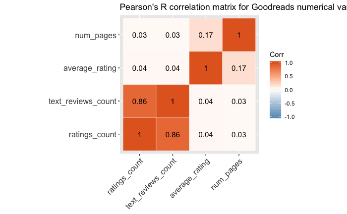

```r
ggcorrplot(goodreads_corr_pearson_round2, hc.order = TRUE,
   lab = TRUE,
   title = "Pearson's R correlation matrix for Goodreads numerical variables",
   outline.col = "white",
   ggtheme = ggplot2::theme_gray,
   colors = c("#6D9EC1", "white", "#E46726"))
```

[figure not shown]

```r
ggcorrplot(goodreads_corr_kendall_round2, hc.order = TRUE,
   lab = TRUE,
   title = "Pearson's R correlation matrix for Goodreads numerical variables",
   outline.col = "white",
   ggtheme = ggplot2::theme_gray,
   colors = c("#6D9EC1", "white", "#E46726"))
```

[figure not shown]

```r
ggcorrplot(goodreads_corr_spearman_round2, hc.order = TRUE,
   lab = TRUE,
   title = "Pearson's R correlation matrix for Goodreads numerical variables",
   outline.col = "white",
   ggtheme = ggplot2::theme_gray,
   colors = c("#6D9EC1", "white", "#E46726"))
```

From the three correlation matrices above, we can see that there is only one pair of numerical variables that are strongly correlated to each other, which is ratings_count and text_reviews_count. All of the correlation coefficients of these two variables, regardless of the method used, are always greater than 0.8, which can be considered to be a strong correlation. The remaining pairs of variables show little positive correlation, with all the remaining coefficients of less than 0.2, some are even less than 0.05.

This shows an intuitive result that the more readers rate a book on a scale of 0 to 5, the more readers will leave a written text review for the same book.

## Histogram plot of numerical variables

First, we will plot the histograms of the numerical/integer variables, including average_rating, num_pages, ratings_count and text_reviews_count.

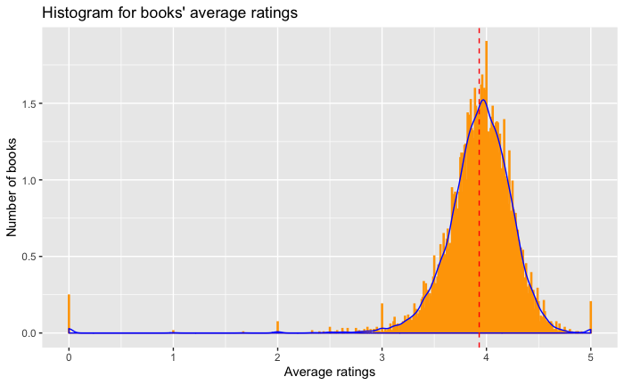

```r
ggplot(data = goodreads, aes(x = goodreads$average_rating)) +
    geom_histogram(aes(y = ..density..),binwidth = 0.01, color='orange', fill='orange') +
    geom_density(colour="blue", lwd = 0.5, alpha=0.5) +
    labs(title="Histogram for books' average ratings", x = "Average ratings", y = "Number of books") +
    geom_vline(data = goodreads, xintercept = mean(goodreads$average_rating, na.rm = TRUE), color = "red", linetype = "dashed", size = 0.5)
```

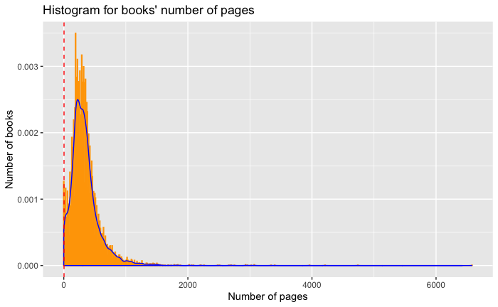

```r
ggplot(data = goodreads, aes(x = goodreads$num_pages)) +
    geom_histogram(aes(y = ..density..),binwidth = 10, color='orange', fill='orange') +
    geom_density(colour="blue", lwd = 0.5, alpha=0.5) +
    labs(title="Histogram for books' number of pages", x = "Number of pages", y = "Number of books") +
    geom_vline(data = goodreads, xintercept = mean(goodreads$average_rating, na.rm = TRUE), color = "red", linetype = "dashed", size = 0.5)
```

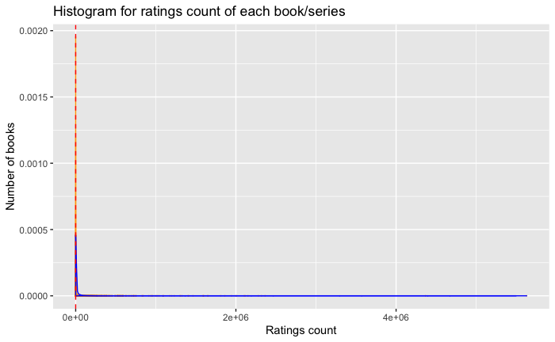

```r
ggplot(data = goodreads, aes(x = goodreads$ratings_count)) +
    geom_histogram(aes(y = ..density..),binwidth = 100, color='orange', fill='orange') +
    geom_density(colour="blue", lwd = 0.5, alpha=0.5) +
    labs(title="Histogram for ratings count of each book/series", x = "Ratings count", y = "Number of books") +
    geom_vline(data = goodreads, xintercept = mean(goodreads$average_rating, na.rm = TRUE), color = "red", linetype = "dashed", size = 0.5)
```

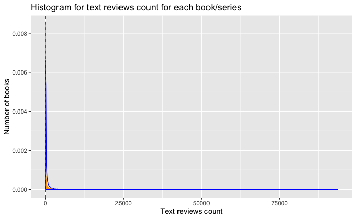

```r
ggplot(data = goodreads, aes(x = goodreads$text_reviews_count)) +
    geom_histogram(aes(y = ..density..),binwidth = 50 , color='orange', fill='orange') +
    geom_density(colour="blue", lwd = 0.5, alpha=0.5) +
    labs(title="Histogram for text reviews count for each book/series", x = "Text reviews count", y = "Number of books") +
    geom_vline(data = goodreads, xintercept = mean(goodreads$average_rating, na.rm = TRUE), color = "red", linetype = "dashed", size = 0.5)
```

The histogram of average_ratings shows that most of the ratings lie between 3 and 5. The distribution of ratings between 3 and 5 seems to be familiar to a normal distribution (i.e most of the ratings focus around 4, and the density decreases upon reaching the edges). Later, we will investigate this distribution and test how close is it to the normal distribution.

With the histogram of num_pages, most of the books have less than 1000 pages, with many of them having 250-500 pages. Later, we will also zoom into this part of the histogram to have a closer look of the distribution.

## Basic statistics of numerical variables

First, as R does not have a built in function to calculate the mode of a dataset, we proceed to define that function ourselves as follow.

```r
# Define the function getmode in R to get the mode of data (appearance with highest frequency)
getmode <- function(v) {
   uniqv <- unique(v)
   uniqv[which.max(tabulate(match(v, uniqv)))]
}
```

Now, we will generate a table of basic properties of each variable.

```r
basic_statistics_goodreads <- data.frame(matrix(NA, ncol = 13, nrow = 10))
names(basic_statistics_goodreads) <- c('Variable',
                             'Minimum score',
                             '25th percentile',
                             'Median',
                             'Mean score',
                             '75th percentile',
                             'Maximum score',
                             'Value with highest frequency (mode)',
                             'Frequency of mode',
                             'Standard Deviation',
                             'SE Mean',
                             'Skewness',
                             'Kurtosis')
for(i in c(4,8:10)) {
  basic_statistics_goodreads[i,1] <- colnames(goodreads)[i]
  basic_statistics_goodreads[i,2] <- min(goodreads[,i], na.rm = TRUE)
  basic_statistics_goodreads[i,3] <- quantile(goodreads[,i], 0.25, na.rm = TRUE)
  basic_statistics_goodreads[i,4] <- quantile(goodreads[,i], 0.5, na.rm = TRUE)
  basic_statistics_goodreads[i,5] <- mean(goodreads[,i], na.rm = TRUE)
  basic_statistics_goodreads[i,6] <- quantile(goodreads[,i], 0.75, na.rm = TRUE)
  basic_statistics_goodreads[i,7] <- max(goodreads[,i], na.rm = TRUE)
  basic_statistics_goodreads[i,8] <- getmode(na.omit(goodreads[,i]))
  basic_statistics_goodreads[i,9] <- sum(goodreads[,i] == basic_statistics_goodreads[i,8])
  basic_statistics_goodreads[i,10] <- sd(goodreads[,i], na.rm = TRUE)
  basic_statistics_goodreads[i,11] <- std.error(goodreads[,i], na.rm = TRUE)
  basic_statistics_goodreads[i,12] <- skewness(goodreads[,i], na.rm = TRUE)
  basic_statistics_goodreads[i,13] <- kurtosis(goodreads[,i], na.rm = TRUE)
}
basic_statistics_goodreads <- na.omit(basic_statistics_goodreads)
View(basic_statistics_goodreads)
```

[output not shown]

First of all, we see an interesting fact that the mode of text_reviews_count is 0 (more than 900 books receive 0 text reviews), which means that books having 0 text reviews occur the most frequently in the dataset. Moreover, the mode of average_ratings is also exactly 4.0, which shows that readers are really generous with the books they are reading.

We also note that the 75th percentile of each variable, apart from average_ratings, is relatively very small comparing to the maximum, which can also explain the positive skewness of those variables.

All 4 variables have a positive kurtosis, which shows that the distribution of these variables have heavier tails than the normal distribution with the same mean and standard deviation.

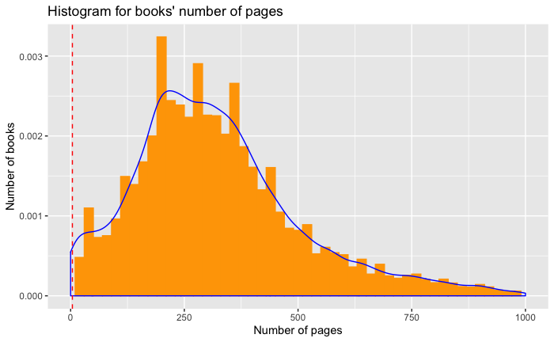

```r
ggplot(data = goodreads, aes(x = goodreads$num_pages)) +
    geom_histogram(aes(y = ..density..),binwidth = 20, color='orange', fill='orange') +
    xlim(c(0,1000)) +
    geom_density(colour="blue", lwd = 0.5, alpha=0.5) +
    labs(title="Histogram for books' number of pages", x = "Number of pages", y = "Number of books") +
    geom_vline(data = goodreads, xintercept = mean(goodreads$average_rating, na.rm = TRUE), color = "red", linetype = "dashed", size = 0.5)
```

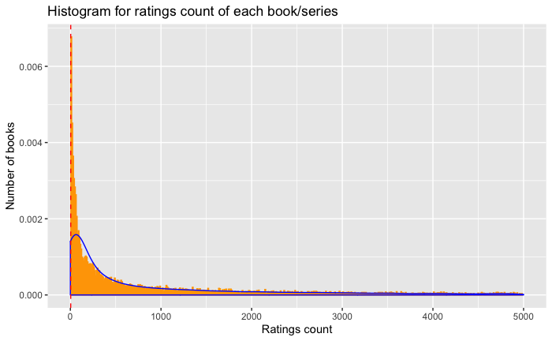

```r
ggplot(data = goodreads, aes(x = goodreads$ratings_count)) +
    geom_histogram(aes(y = ..density..),binwidth = 10, color='orange', fill='orange') +
    xlim(c(0,5000)) +
    geom_density(colour="blue", lwd = 0.5, alpha=0.5) +
    labs(title="Histogram for ratings count of each book/series", x = "Ratings count", y = "Number of books") +
    geom_vline(data = goodreads, xintercept = mean(goodreads$average_rating, na.rm = TRUE), color = "red", linetype = "dashed", size = 0.5)
```

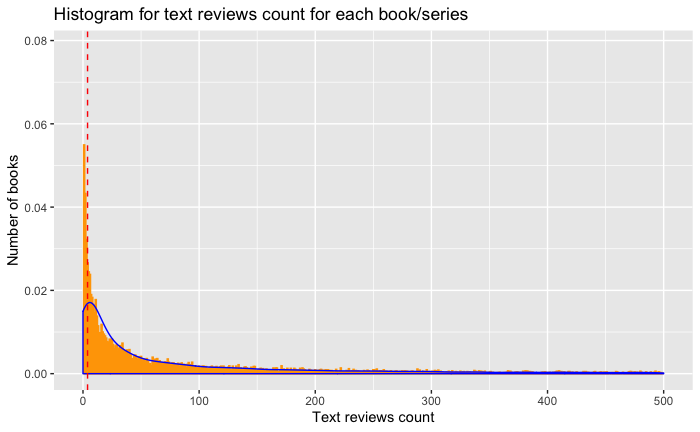

```r
ggplot(data = goodreads, aes(x = goodreads$text_reviews_count)) +
    geom_histogram(aes(y = ..density..),binwidth = 1 , color='orange', fill='orange') +
    xlim(c(0,500)) +
    geom_density(colour="blue", lwd = 0.5, alpha=0.5) +
    labs(title="Histogram for text reviews count for each book/series", x = "Text reviews count", y = "Number of books") +
    geom_vline(data = goodreads, xintercept = mean(goodreads$average_rating, na.rm = TRUE), color = "red", linetype = "dashed", size = 0.5)
```

Considering number of pages, most books have the number of pages of around 175 - 325. Then, the number of book inversely proportional to the number of pages (i.e the number of books is decreasing with respect to their length).

## Scatterplot of pairs of numerical variables in the dataset

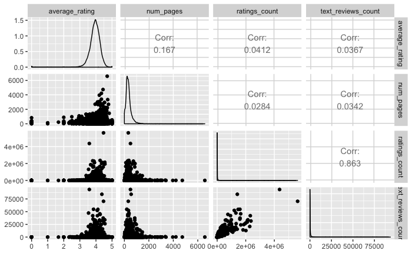

```r
ggpairs(with(goodreads, data.frame(average_rating, num_pages, ratings_count, text_reviews_count)))
```

From this scatterplot matrix, we can see that, apart from the pairs ratings_count and text_reviews_count, the remaining shows little to no correlation. All of the scatterplot shows a nearly vertical trend line (i.e there is no linear correlation between the two variables plotted).

## Rating distribustion of books in the dataset

First, we divide the ratings into five different ranges: - Between 0 and 1 - Between 1 and 2 - Between 2 and 3 - Between 3 and 4 - Between 4 and 5

We calculate the number of books within each range, along with their percentages.

```r
rating_distribution_goodreads <- data.frame(matrix(0, ncol = 3, nrow = 5))
names(rating_distribution_goodreads) <- c('',
                             'number_of_books',
                             'percentage')
for(i in c(1:5)) {
  rating_distribution_goodreads[i,1] <- paste('Between',i-1,'and',i)
}
for(i in c(1:nrow(goodreads))) {
  if (goodreads[i,4] >= 0 & goodreads[i,4] < 1) {
    rating_distribution_goodreads[1,2] = rating_distribution_goodreads[1,2] + 1
  }
  if (goodreads[i,4] >= 1 & goodreads[i,4] < 2) {
    rating_distribution_goodreads[2,2] = rating_distribution_goodreads[2,2] + 1
    }
  if (goodreads[i,4] >= 2 & goodreads[i,4] < 3) {
    rating_distribution_goodreads[3,2] = rating_distribution_goodreads[3,2] + 1
    }
  if (goodreads[i,4] >= 3 & goodreads[i,4] < 4) {
    rating_distribution_goodreads[4,2] = rating_distribution_goodreads[4,2] + 1
    }
  if (goodreads[i,4] >= 4 & goodreads[i,4] < 5) {
    rating_distribution_goodreads[5,2] = rating_distribution_goodreads[5,2] + 1
  }
}
rating_distribution_goodreads$percentage <- round((rating_distribution_goodreads$number_of_books)/nrow(goodreads)*100,digits = 2)
rating_distribution_goodreads
```

|  | number_of_books | percentage |
| --- | --- | --- |
| Between 0 and 1 | 34 | 0.25 |
| Between 1 and 2 | 3 | 0.02 |
| Between 2 and 3 | 72 | 0.53 |
| Between 3 and 4 | 7586 | 55.32 |
| Between 4 and 5 | 5991 | 43.69 |

Then, we will plot two different pie charts, a traditional one and a square pie chart, to observe the distribution of books within ranges.

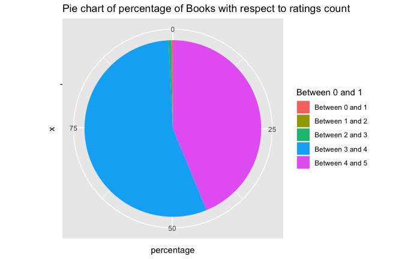

```r
ggplot(data=rating_distribution_goodreads, aes(x="", y=percentage,
       fill = factor(rating_distribution_goodreads[,1]), )) +
       geom_bar(width = 1, stat = "identity") +
       ggtitle("Pie chart of percentage of Books with respect to ratings count") +
       coord_polar(theta="y", start = 0) +
       labs(fill = factor(rating_distribution_goodreads[,1]))
```

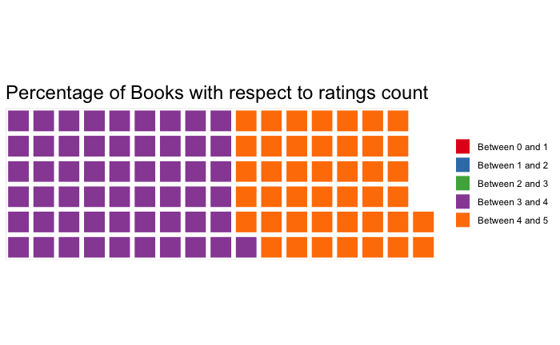

```r
rating_distribution_number <- c(`Between 0 and 1`= 0.25, `Between 1 and 2`= 0.02, `Between 2 and 3`= 0.53, `Between 3 and 4`= 55.32, `Between 4 and 5`= 43.69)
waffle(rating_distribution_number, rows=6,
       colors=brewer.pal(5,"Set1"),
       title="Percentage of Books with respect to ratings count")
```

We can see that, more than half of the books are rated between 3 and 4 points, while most the remaining books are ranked between 4 and 5. There are a total of 13577 books rated between 3 and 5, which counts up to 99% of the books in the dataset.

## Books with the most occurences in the dataset

```r
book_frequency <- data.frame(table(goodreads$title), stringsAsFactors = FALSE)
names(book_frequency) <- c('title','frequency')
book_frequency <- book_frequency[order(-book_frequency$frequency),]
head(book_frequency)
```

|  | title | frequency |
| --- | --- | --- |
| 8 | 'Salem's Lot | 11 |
| 6233 | One Hundred Years of Solitude | 11 |
| 8407 | The Brothers Karamazov | 10 |
| 9461 | The Iliad | 10 |
| 257 | A Midsummer Night's Dream | 9 |
| 377 | A Tale of Two Cities | 9 |

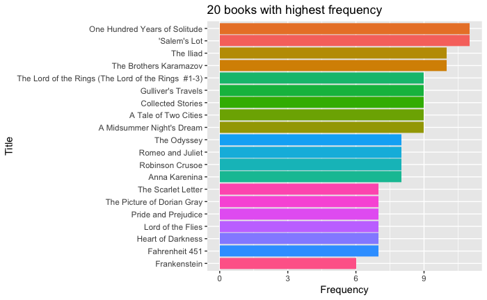

```r
book_frequency_top20 <- book_frequency[c(1:20),]
ggplot(data=book_frequency_top20, aes(x=reorder(title, frequency),y=frequency, fill = factor(c(1:nrow(book_frequency_top20))))) +
  theme(legend.position = "none") +
  geom_bar(stat="identity") +
  coord_flip() +
  ggtitle('20 books with highest frequency') +
  labs(x = "Title", y = "Frequency")
```

Above, we have plotted the 20 books with the most appearances in the dataset. We can see that “One Hundred Year of Solitude” and “Salem’s Lot” are the two books appearing the most, with 11 times for each book.

These books are published again and again, each time with another publisher. This shows that these are still in great demand, despite the flow of time.

## Languages written in books/series

```r
book_language <- data.frame(table(goodreads$language_code), stringsAsFactors = FALSE)
names(book_language) <- c('language','frequency')
book_language <- book_language[order(-book_language$frequency),]
book_language$percentage <- round(book_language$frequency/nrow(goodreads)*100, digits = 2)
head(book_language)
```

|  | language | frequency | percentage |
| --- | --- | --- | --- |
| 8 | eng | 10594 | 77.25 |
| 7 | en-US | 1699 | 12.39 |
| 25 | spa | 419 | 3.06 |
| 6 | en-GB | 341 | 2.49 |
| 11 | ger | 238 | 1.74 |
| 10 | fre | 209 | 1.52 |

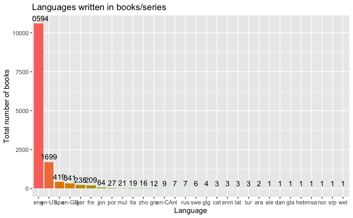

```r
ggplot(book_language, aes(x=reorder(language,-frequency),y=frequency, fill = factor(c(1:nrow(book_language))))) +
  theme(legend.position = "none") +
  geom_bar(stat="identity") +
  ggtitle('Languages written in books/series') +
  labs(x = "Language", y = "Total number of books") +
  geom_text(aes(label=frequency), vjust=-0.5)
```

We can easily see that most of the books in this dataset is written in English. Two most used languages are English and English-US, while within 6 most commonly used languages, English and its different versions (eng-US and eng-GB) counts up to half of them. Combining all the different versions of this language, English is written in 12634 books, which is 92,12% of all the books. Apart from English, Spanish, the third commonly used language, only has 419 books, which is 3.1% of the books in this dataset.

# 10 Books with the highest average rating

```r
book_average_rating <- goodreads[order(-goodreads$average_rating),]
book_average_rating_top10 <- book_average_rating[c(1:10),]
book_average_rating_top10
```

|  | bookID | title | authors | average_rating | isbn | isbn13 | language_code | num_pages | ratings_count | text_reviews_count |
| --- | --- | --- | --- | --- | --- | --- | --- | --- | --- | --- |
| 706 | 2034 | Comoediae 1: Acharenses/Equites/Nubes/Vespae/Pax/Aves | Aristophanes-F.W. Hall-W.M. Geldart | 5 | 0198145047 | 9780198145042 | grc | 364 | 0 | 0 |
| 880 | 2560 | Willem de Kooning: Late Paintings | Julie Sylvester-David Sylvester | 5 | 382960226X | 9783829602266 | eng | 83 | 1 | 0 |
| 964 | 2843 | Literature Circle Guide: Bridge to Terabithia: Everything You Need For Successful Literature Circles That Get Kids Thinking Talking Writing—and Loving Literature | Tara MacCarthy | 5 | 0439271711 | 9780439271714 | eng | 32 | 4 | 1 |
| 1443 | 4287 | Middlesex Borough (Images of America: New Jersey) | Middlesex Borough Heritage Committee | 5 | 0738511676 | 9780738511672 | eng | 128 | 2 | 0 |
| 1625 | 4874 | The Decoration of the Torre de la Parada (Corpus Rubenianum Ludwig Burchard Part IX) (Corpus Rubenianum Ludwig Burchard) | Svetlana Alpers | 5 | 0199210152 | 9780199210152 | eng | 532 | 1 | 0 |
| 2989 | 9338 | Insights: Talks On The Nature Of Existence | Frederick P. Lenz | 5 | 1932206086 | 9781932206081 | eng | 304 | 1 | 0 |
| 4942 | 14741 | Zone of the Enders: The 2nd Runner Official Strategy Guide | Tim Bogenn | 5 | 0744002354 | 9780744002355 | eng | 128 | 2 | 0 |
| 5791 | 17224 | The Diamond Color Meditation: Color Path to the Soul | John Diamond | 5 | 1890995525 | 9781890995522 | eng | 74 | 5 | 3 |
| 6082 | 18184 | The Complete Theory Fun Factory: Music Theory Puzzles and Games for the Early Grades | Ian Martin-Katie Elliott | 5 | 0851621813 | 9780851621814 | eng | 96 | 1 | 0 |
| 6601 | 19786 | The Goon Show Volume 4: My Knees Have Fallen Off! | NOT A BOOK | 5 | 0563388692 | 9780563388692 | eng | 2 | 3 | 0 |

[figure not shown]

```r
ggplot(data=book_average_rating_top10, aes(x=reorder(title, average_rating),y=average_rating, fill = factor(c(1:nrow(book_average_rating_top10))))) +
  theme(legend.position = "none") +
  geom_bar(stat="identity") +
  coord_flip() +
  scale_fill_brewer(palette="Paired") +
  ggtitle('Books/series with highest number of ratings') +
  labs(x = "Book/series", y = "Number of ratings") +
  geom_text(
    aes(label = average_rating), colour = "black",
    hjust = -0.1, size = 2,
    position = position_dodge(width = 1),
    inherit.aes = TRUE
  )
```

```r
author_highest_book_average_rating <- data.frame(table(book_average_rating_top10$authors))
names(author_highest_book_average_rating) <- c('author', 'number_of_books')
author_highest_book_average_rating <- author_highest_book_average_rating[order(-author_highest_book_average_rating$number_of_books),]
author_highest_book_average_rating
```

|  | author | number_of_books |
| --- | --- | --- |
| 1 | Aristophanes-F.W. Hall-W.M. Geldart | 1 |
| 2 | Frederick P. Lenz | 1 |
| 3 | Ian Martin-Katie Elliott | 1 |
| 4 | John Diamond | 1 |
| 5 | Julie Sylvester-David Sylvester | 1 |
| 6 | Middlesex Borough Heritage Committee | 1 |
| 7 | NOT A BOOK | 1 |
| 8 | Svetlana Alpers | 1 |
| 9 | Tara MacCarthy | 1 |
| 10 | Tim Bogenn | 1 |

Surprisingly, all 10 of the highest rating books have the maximum rating, 5. As a result, we will investigate all the books that have the rating of 5 in this dataset.

```r
books_rating_5 <- goodreads[goodreads$average_rating == 5,]
books_rating_5 <- books_rating_5[order(-books_rating_5$ratings_count),]
books_rating_5
```

|  | bookID | title | authors | average_rating | isbn | isbn13 | language_code | num_pages | ratings_count | text_reviews_count |
| --- | --- | --- | --- | --- | --- | --- | --- | --- | --- | --- |
| 5791 | 17224 | The Diamond Color Meditation: Color Path to the Soul | John Diamond | 5 | 1890995525 | 9781890995522 | eng | 74 | 5 | 3 |
| 11078 | 36781 | Bubbles in the Middle (The Powerpuff Girls Plus You Club #16) | Aaron Rosenberg-Christopher Cook | 5 | 0439332613 | 9780439332613 | eng | 64 | 5 | 0 |
| 964 | 2843 | Literature Circle Guide: Bridge to Terabithia: Everything You Need For Successful Literature Circles That Get Kids Thinking Talking Writing—and Loving Literature | Tara MacCarthy | 5 | 0439271711 | 9780439271714 | eng | 32 | 4 | 1 |
| 8410 | 26557 | Calvin y Hobbes 10: El tiempo está loco | Bill Watterson | 5 | 8440685416 | 9788440685414 | spa | 48 | 4 | 0 |
| 6601 | 19786 | The Goon Show Volume 4: My Knees Have Fallen Off! | NOT A BOOK | 5 | 0563388692 | 9780563388692 | eng | 2 | 3 | 0 |
| 11730 | 39829 | His Princess Devotional: A Royal Encounter With Your King | Sheri Rose Shepherd | 5 | 1590529626 | 9781590529621 | eng | 240 | 3 | 0 |
| 1443 | 4287 | Middlesex Borough (Images of America: New Jersey) | Middlesex Borough Heritage Committee | 5 | 0738511676 | 9780738511672 | eng | 128 | 2 | 0 |
| 4942 | 14741 | Zone of the Enders: The 2nd Runner Official Strategy Guide | Tim Bogenn | 5 | 0744002354 | 9780744002355 | eng | 128 | 2 | 0 |
| 6603 | 19788 | The Goon Show Volume 11: He's Fallen in the Water! | NOT A BOOK | 5 | 0563388323 | 9780563388326 | eng | 2 | 2 | 0 |
| 6793 | 20954 | Winchester Shotguns | Dennis Adler-R.L. Wilson | 5 | 0785821082 | 9780785821083 | eng | 372 | 2 | 0 |

[output cut: 18 more lines]

```r
print(paste('There are',nrow(books_rating_5),'books that receive an average rating of 5.'))
```

```
[1] "There are 28 books that receive an average rating of 5."
```

We can easily see that all of the books with average ratings of 5 receive very few ratings. The maximum ratings count among these books are 5. Specifically, there are 4 books that receive 0 ratings, and still receive an average rating of 5, which is not supposed to happen. Moreover, 23/28 books in the list receive 0 text reviews. We can not consider these books to be the ones with highest average rating, as the ratings count is too low.

Instead, we propose the following method: We only consider the average rating of books with more than 1000 ratings.

```r
book_1000_ratings_count <- goodreads[goodreads$ratings_count >= 1000,]
book_1000_ratings_count <- book_1000_ratings_count[order(-book_1000_ratings_count$average_rating),]
book_1000_ratings_count
```

|  | bookID | title | authors | average_rating | isbn | isbn13 | language_code | num_pages | ratings_count | text_reviews_count |
| --- | --- | --- | --- | --- | --- | --- | --- | --- | --- | --- |
| 7929 | 24812 | The Complete Calvin and Hobbes | Bill Watterson | 4.82 | 0740748475 | 9780740748479 | eng | 1456 | 31249 | 920 |
| 6 | 8 | Harry Potter Boxed Set Books 1-5 (Harry Potter #1-5) | J.K. Rowling | 4.78 | 0439682584 | 9780439682589 | eng | 2690 | 38872 | 154 |
| 7931 | 24814 | It's a Magical World (Calvin and Hobbes #11) | Bill Watterson | 4.76 | 0836221362 | 9780836221367 | eng | 176 | 23336 | 294 |
| 7932 | 24815 | The Indispensable Calvin and Hobbes | Bill Watterson | 4.74 | 0751500283 | 9780751500288 | eng | 255 | 15641 | 291 |
| 8 | 10 | Harry Potter Collection (Harry Potter #1-6) | J.K. Rowling | 4.73 | 0439827604 | 9780439827607 | eng | 3342 | 27410 | 820 |
| 7933 | 24816 | Homicidal Psycho Jungle Cat (Calvin and Hobbes #9) | Bill Watterson | 4.72 | 0836217691 | 9780836217698 | eng | 176 | 14952 | 277 |
| 7937 | 24820 | Calvin and Hobbes: Sunday Pages 1985-1995: An Exhibition Catalogue | Bill Watterson | 4.71 | 0740721356 | 9780740721359 | eng | 96 | 3537 | 82 |
| 4408 | 13358 | The Everyday Life Bible: The Power of God's Word for Everyday Living | Anonymous-Joyce Meyer | 4.70 | 0446578274 | 9780446578271 | en-US | 2208 | 1715 | 56 |
| 6758 | 20749 | Study Bible: NIV | Anonymous | 4.70 | 0310929555 | 9780310929550 | eng | 2198 | 4092 | 192 |
| 7828 | 24520 | The Complete Aubrey/Maturin Novels (5 Volumes) | Patrick O'Brian | 4.70 | 039306011X | 9780393060119 | eng | 6576 | 1287 | 82 |

[output cut: 990 more lines]

```r
book_1000_ratings_count_top10 <- book_1000_ratings_count[c(1:10),]
book_1000_ratings_count_top10
```

|  | bookID | title | authors | average_rating | isbn | isbn13 | language_code | num_pages | ratings_count | text_reviews_count |
| --- | --- | --- | --- | --- | --- | --- | --- | --- | --- | --- |
| 7929 | 24812 | The Complete Calvin and Hobbes | Bill Watterson | 4.82 | 0740748475 | 9780740748479 | eng | 1456 | 31249 | 920 |
| 6 | 8 | Harry Potter Boxed Set Books 1-5 (Harry Potter #1-5) | J.K. Rowling | 4.78 | 0439682584 | 9780439682589 | eng | 2690 | 38872 | 154 |
| 7931 | 24814 | It's a Magical World (Calvin and Hobbes #11) | Bill Watterson | 4.76 | 0836221362 | 9780836221367 | eng | 176 | 23336 | 294 |
| 7932 | 24815 | The Indispensable Calvin and Hobbes | Bill Watterson | 4.74 | 0751500283 | 9780751500288 | eng | 255 | 15641 | 291 |
| 8 | 10 | Harry Potter Collection (Harry Potter #1-6) | J.K. Rowling | 4.73 | 0439827604 | 9780439827607 | eng | 3342 | 27410 | 820 |
| 7933 | 24816 | Homicidal Psycho Jungle Cat (Calvin and Hobbes #9) | Bill Watterson | 4.72 | 0836217691 | 9780836217698 | eng | 176 | 14952 | 277 |
| 7937 | 24820 | Calvin and Hobbes: Sunday Pages 1985-1995: An Exhibition Catalogue | Bill Watterson | 4.71 | 0740721356 | 9780740721359 | eng | 96 | 3537 | 82 |
| 4408 | 13358 | The Everyday Life Bible: The Power of God's Word for Everyday Living | Anonymous-Joyce Meyer | 4.70 | 0446578274 | 9780446578271 | en-US | 2208 | 1715 | 56 |
| 6758 | 20749 | Study Bible: NIV | Anonymous | 4.70 | 0310929555 | 9780310929550 | eng | 2198 | 4092 | 192 |
| 7828 | 24520 | The Complete Aubrey/Maturin Novels (5 Volumes) | Patrick O'Brian | 4.70 | 039306011X | 9780393060119 | eng | 6576 | 1287 | 82 |

[figure not shown]

```r
ggplot(data=book_1000_ratings_count_top10, aes(x=reorder(title, average_rating),y=average_rating, fill = factor(c(1:nrow(book_1000_ratings_count_top10))))) +
  theme(legend.position = "none") +
  geom_bar(stat="identity") +
  coord_flip() +
  scale_fill_brewer(palette="Paired") +
  ggtitle('Books/series with highest number of ratings') +
  labs(x = "Book/series", y = "Number of ratings") +
  geom_text(
    aes(label = average_rating), colour = "black",
    hjust = -0.1, size = 2,
    position = position_dodge(width = 1),
    inherit.aes = TRUE
  )
```

```r
author_book_1000_ratings_count <- data.frame(table(book_1000_ratings_count_top10$authors))
names(author_book_1000_ratings_count) <- c('author', 'number_of_books')
author_book_1000_ratings_count <- author_book_1000_ratings_count[order(-author_book_1000_ratings_count$number_of_books),]
author_book_1000_ratings_count
```

|  | author | number_of_books |
| --- | --- | --- |
| 3 | Bill Watterson | 5 |
| 4 | J.K. Rowling | 2 |
| 1 | Anonymous | 1 |
| 2 | Anonymous-Joyce Meyer | 1 |
| 5 | Patrick O'Brian | 1 |

We can see that, there is only 6059 books that have the ratings count of more than or equal to 1000, which accounts for 44.18% of all the books in the dataset.

Within these 6059 books, the highest has the average rating of 4.82, while the lowest rating among the top 10 books is 4.7.

Among those 10 books, half of them are written by Bill Watterson, two are from J.K. Rowling, one from Patrick O’Brian, one from Joyce Meyer and one from anonymous. We can easily see that Bill Watterson has written books that receive very high ratings from a large number of readers. Two among the top 10 from J.K Rowling are both sets of Harry Potter (one set of #1-5 and one set of #1-6).

Another interesting fact is that all books in top 10 are written in English, with one specifically written in en-US.

# 10 longest books in the dataset

```r
book_num_pages <- goodreads[order(-goodreads$num_pages),]
book_num_pages_top10 <- book_num_pages[c(1:10),]
book_num_pages_top10
```

|  | bookID | title | authors | average_rating | isbn | isbn13 | language_code | num_pages | ratings_count | text_reviews_count |
| --- | --- | --- | --- | --- | --- | --- | --- | --- | --- | --- |
| 7828 | 24520 | The Complete Aubrey/Maturin Novels (5 Volumes) | Patrick O'Brian | 4.70 | 039306011X | 9780393060119 | eng | 6576 | 1287 | 82 |
| 8186 | 25587 | The Second World War | Winston S. Churchill-John Keegan | 4.44 | 039541685X | 9780395416853 | eng | 4736 | 1437 | 94 |
| 6269 | 18796 | In Search of Lost Time (6 Volumes) | Marcel Proust-C.K. Scott Moncrieff-Andreas Mayor-Terence Kilmartin-D.J. Enright-Richard Howard | 4.34 | 0812969642 | 9780812969641 | eng | 4211 | 7255 | 333 |
| 13594 | 47174 | The Norton Anthology of English Literature Vols A-C: The Middle Ages Through the Restoration and the Eighteenth Century | M.H. Abrams-Stephen Greenblatt-James Noggle-James Simpson-Jon Stallworthy-Jack Stillinger-Carol T. Christ-Lawrence Lipking-Jahan Ramazani-George M. Logan-Alfred David-Katharine Eisaman Maus-Barbara Ki… | 4.21 | 0393928330 | 9780393928334 | eng | 3956 | 44 | 0 |
| 12950 | 44613 | Remembrance of Things Past (Boxed Set) | Marcel Proust-C.K. Scott Moncrieff-Frederick A. Blossom-Joseph Wood Crutch | 4.34 | 0701125594 | 9780701125592 | eng | 3400 | 6 | 1 |
| 8 | 10 | Harry Potter Collection (Harry Potter #1-6) | J.K. Rowling | 4.73 | 0439827604 | 9780439827607 | eng | 3342 | 27410 | 820 |
| 13589 | 47163 | The Norton Anthology of English Literature Volume 2: The Romantic Period through the Twentieth Century | M.H. Abrams-Stephen Greenblatt-James Simpson-Jon Stallworthy-Katharine Eisaman Maus-Jack Stillinger-Barbara Kiefer Lewalski-Lawrence Lipking-Jahan Ramazani-Alfred David-Carol T. Christ-Deidre Shauna L… | 4.23 | 0393925323 | 9780393925326 | en-US | 3072 | 2422 | 66 |
| 13590 | 47164 | The Norton Anthology of English Literature Volume 1: The Middle Ages through the Restoration & the Eighteenth Century | M.H. Abrams-Stephen Greenblatt | 4.21 | 0393925315 | 9780393925319 | en-US | 3072 | 7636 | 112 |
| 8208 | 25709 | Summa Theologica 5 Vols | Thomas Aquinas | 4.10 | 0870610635 | 9780870610639 | eng | 3020 | 2673 | 86 |
| 12873 | 44242 | Civil War: a Narrative | Shelby Foote | 4.53 | 0394749138 | 9780394749136 | eng | 2965 | 213 | 17 |

[figure not shown]

```r
ggplot(data=book_num_pages_top10, aes(x=reorder(title, num_pages),y=num_pages, fill = factor(c(1:nrow(book_num_pages_top10))))) +
  theme(legend.position = "none") +
  geom_bar(stat="identity") +
  coord_flip() +
  scale_fill_brewer(palette="Paired") +
  ggtitle('Books/series with highest number of ratings') +
  labs(x = "Book/series", y = "Number of ratings") +
  geom_text(
    aes(label = num_pages), colour = "black",
    hjust = -0.1, size = 2,
    position = position_dodge(width = 1),
    inherit.aes = TRUE
  )
```

```r
author_book_num_pages <- data.frame(table(book_num_pages_top10$authors))
names(author_book_num_pages) <- c('author', 'number_of_books')
author_book_num_pages <- author_book_num_pages[order(-author_book_num_pages$number_of_books),]
author_book_num_pages
```

|  | author | number_of_books |
| --- | --- | --- |
| 1 | J.K. Rowling | 1 |
| 2 | M.H. Abrams-Stephen Greenblatt | 1 |
| 3 | M.H. Abrams-Stephen Greenblatt-James Noggle-James Simpson-Jon Stallworthy-Jack Stillinger-Carol T. Christ-Lawrence Lipking-Jahan Ramazani-George M. Logan-Alfred David-Katharine Eisaman Maus-Barbara Ki… | 1 |
| 4 | M.H. Abrams-Stephen Greenblatt-James Simpson-Jon Stallworthy-Katharine Eisaman Maus-Jack Stillinger-Barbara Kiefer Lewalski-Lawrence Lipking-Jahan Ramazani-Alfred David-Carol T. Christ-Deidre Shauna L… | 1 |
| 5 | Marcel Proust-C.K. Scott Moncrieff-Andreas Mayor-Terence Kilmartin-D.J. Enright-Richard Howard | 1 |
| 6 | Marcel Proust-C.K. Scott Moncrieff-Frederick A. Blossom-Joseph Wood Crutch | 1 |
| 7 | Patrick O'Brian | 1 |
| 8 | Shelby Foote | 1 |
| 9 | Thomas Aquinas | 1 |
| 10 | Winston S. Churchill-John Keegan | 1 |

## 10 Books with the highest number of ratings count

```r
book_ratings_count <- goodreads[order(-goodreads$ratings_count),]
book_ratings_count_top10 <- book_ratings_count[c(1:10),]
book_ratings_count_top10
```

|  | bookID | title | authors | average_rating | isbn | isbn13 | language_code | num_pages | ratings_count | text_reviews_count |
| --- | --- | --- | --- | --- | --- | --- | --- | --- | --- | --- |
| 3 | 3 | Harry Potter and the Sorcerer's Stone (Harry Potter #1) | J.K. Rowling | 4.47 | 0439554934 | 9780439554930 | eng | 320 | 5629932 | 70390 |
| 12254 | 41865 | Twilight (Twilight #1) | Stephenie Meyer | 3.59 | 0316015849 | 9780316015844 | eng | 498 | 4367341 | 93619 |
| 2001 | 5907 | The Hobbit or There and Back Again | J.R.R. Tolkien | 4.26 | 0618260307 | 9780618260300 | eng | 366 | 2364968 | 31664 |
| 1718 | 5107 | The Catcher in the Rye | J.D. Salinger | 3.80 | 0316769177 | 9780316769174 | eng | 277 | 2318478 | 42016 |
| 341 | 960 | Angels & Demons (Robert Langdon #1) | Dan Brown | 3.88 | 1416524797 | 9781416524793 | eng | 736 | 2279854 | 20851 |
| 5 | 5 | Harry Potter and the Prisoner of Azkaban (Harry Potter #3) | J.K. Rowling | 4.55 | 043965548X | 9780439655484 | eng | 435 | 2149872 | 33964 |
| 5303 | 15881 | Harry Potter and the Chamber of Secrets (Harry Potter #2) | J.K. Rowling | 4.41 | 0439064864 | 9780439064866 | eng | 341 | 2115562 | 32694 |
| 2506 | 7613 | Animal Farm | George Orwell | 3.91 | 0452284244 | 9780452284241 | eng | 122 | 2102616 | 29469 |
| 26 | 34 | The Fellowship of the Ring (The Lord of the Rings #1) | J.R.R. Tolkien | 4.35 | 0618346252 | 9780618346257 | eng | 398 | 2009749 | 12784 |
| 2 | 2 | Harry Potter and the Order of the Phoenix (Harry Potter #5) | J.K. Rowling | 4.49 | 0439358078 | 9780439358071 | eng | 870 | 1996446 | 27613 |

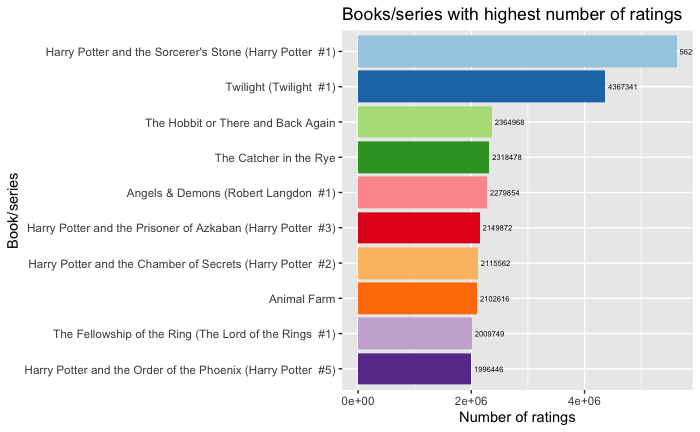

```r
ggplot(data=book_ratings_count_top10, aes(x=reorder(title, ratings_count),y=ratings_count, fill = factor(c(1:nrow(book_ratings_count_top10))))) +
  theme(legend.position = "none") +
  geom_bar(stat="identity") +
  coord_flip() +
  scale_fill_brewer(palette="Paired") +
  ggtitle('Books/series with highest number of ratings') +
  labs(x = "Book/series", y = "Number of ratings") +
  geom_text(
    aes(label = ratings_count), colour = "black",
    hjust = -0.1, size = 2,
    position = position_dodge(width = 1),
    inherit.aes = TRUE
  )
```

```r
author_most_book_ratings_count <- data.frame(table(book_ratings_count_top10$authors))
names(author_most_book_ratings_count) <- c('author', 'number_of_books')
author_most_book_ratings_count <- author_most_book_ratings_count[order(-author_most_book_ratings_count$number_of_books),]
author_most_book_ratings_count
```

|  | author | number_of_books |
| --- | --- | --- |
| 4 | J.K. Rowling | 4 |
| 5 | J.R.R. Tolkien | 2 |
| 1 | Dan Brown | 1 |
| 2 | George Orwell | 1 |
| 3 | J.D. Salinger | 1 |
| 6 | Stephenie Meyer | 1 |

There is a huge gap between the first two most rated books and the remainings. Specifically speaking, there is a 2 million rating gap between Twilight #1 - the second most rated book and “The Hobbit or Three and Back Again” - the third most rated book. Even between the first position, “Harry Potter and the Sorcerer’s Stone” and the second one, there is also a significant gap of about 1.3 million ratings. However, between the third and the 10th position, the gap is just about 350.000 ratings.

About the authors’ list of top 10 books, we can easily see that J.K Rowling and her Harry Potter series are dominating the ratings count, with 4 of her books in the series making their ways to the top 10. - Harry Potter and the Sorcerer’s Stone (Harry Potter #1) at first place - Harry Potter and the Prisoner of Azkaban (Harry Potter #3) at sixth place - Harry Potter and the Chamber of Secrets (Harry Potter #2) at seventh place - Harry Potter and the Order of the Phoenix (Harry Potter #5) at tenth place

Large number of ratings count, alongside with high average rating (all over 4.4), these definitely shows how successful this series have been.

```r
book_text_reviews_count <- goodreads[order(-goodreads$text_reviews_count),]
book_text_reviews_count_top10 <- book_text_reviews_count[c(1:10),]
book_text_reviews_count_top10
```

|  | bookID | title | authors | average_rating | isbn | isbn13 | language_code | num_pages | ratings_count | text_reviews_count |
| --- | --- | --- | --- | --- | --- | --- | --- | --- | --- | --- |
| 12254 | 41865 | Twilight (Twilight #1) | Stephenie Meyer | 3.59 | 0316015849 | 9780316015844 | eng | 498 | 4367341 | 93619 |
| 6368 | 19063 | The Book Thief | Markus Zusak | 4.37 | 0375831002 | 9780375831003 | eng | 552 | 1410666 | 84237 |
| 3 | 3 | Harry Potter and the Sorcerer's Stone (Harry Potter #1) | J.K. Rowling | 4.47 | 0439554934 | 9780439554930 | eng | 320 | 5629932 | 70390 |
| 314 | 865 | The Alchemist | Paulo Coelho-Alan R. Clarke-Özdemir İnce | 3.85 | 0061122416 | 9780061122415 | eng | 197 | 1592632 | 54668 |
| 1212 | 3636 | The Giver | Lois Lowry | 4.12 | 0385732554 | 9780385732550 | eng | 208 | 1464909 | 54469 |
| 12700 | 43641 | Water for Elephants | Sara Gruen | 4.08 | 1565125606 | 9781565125605 | eng | 335 | 1198632 | 52449 |
| 6527 | 19501 | Eat Pray Love | Elizabeth Gilbert | 3.54 | 0143038419 | 9780143038412 | eng | 368 | 1309623 | 47291 |
| 8756 | 28187 | The Lightning Thief (Percy Jackson and the Olympians #1) | Rick Riordan | 4.24 | 0786838655 | 9780786838653 | eng | 377 | 1645445 | 45829 |
| 2442 | 7445 | The Glass Castle | Jeannette Walls | 4.26 | 074324754X | 9780743247542 | eng | 288 | 752358 | 44620 |
| 11447 | 38447 | The Handmaid's Tale | Margaret Atwood | 4.09 | 038549081X | 9780385490818 | eng | 344 | 932832 | 42096 |

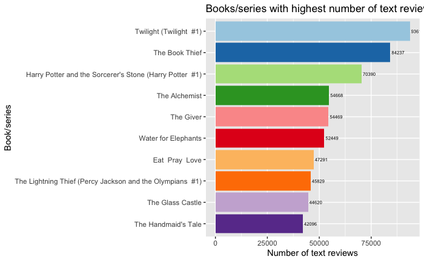

```r
ggplot(data=book_text_reviews_count_top10, aes(x=reorder(title, text_reviews_count),y=text_reviews_count, fill = factor(c(1:nrow(book_text_reviews_count_top10))))) +
  theme(legend.position = "none") +
  geom_bar(stat="identity") +
  coord_flip() +
  scale_fill_brewer(palette="Paired") +
  ggtitle('Books/series with highest number of text reviews') +
  labs(x = "Book/series", y = "Number of text reviews") +
  geom_text(
    aes(label = text_reviews_count), colour = "black",
    hjust = -0.1, size = 2,
    position = position_dodge(width = 1),
    inherit.aes = TRUE
  )
```

```r
author_most_book_text_reviews_count <- data.frame(table(book_text_reviews_count_top10$authors))
names(author_most_book_text_reviews_count) <- c('author', 'number_of_books')
author_most_book_text_reviews_count <- author_most_book_text_reviews_count[order(-author_most_book_text_reviews_count$number_of_books),]
author_most_book_text_reviews_count
```

|  | author | number_of_books |
| --- | --- | --- |
| 1 | Elizabeth Gilbert | 1 |
| 2 | J.K. Rowling | 1 |
| 3 | Jeannette Walls | 1 |
| 4 | Lois Lowry | 1 |
| 5 | Margaret Atwood | 1 |
| 6 | Markus Zusak | 1 |
| 7 | Paulo Coelho-Alan R. Clarke-Özdemir İnce | 1 |
| 8 | Rick Riordan | 1 |
| 9 | Sara Gruen | 1 |
| 10 | Stephenie Meyer | 1 |

Once again, there is a significant gap between the first four positions; after that, the gap is getting much narrower.

Moreover, this time, the author’s list of these books are more widely spread, with 10 different authors, each having one of their books in the top 10 list.

We have seen some familiar names that appear in both top 10 of ratings count and text reviews count. The question is, how many of them are there, and what is the difference between their performance in these two criteria?

## Common books of the two top 10 of ratings count and text reviews count

```r
common_top10 <- intersect(book_text_reviews_count_top10, book_ratings_count_top10)
common_top10
```

| bookID | title | authors | average_rating | isbn | isbn13 | language_code | num_pages | ratings_count | text_reviews_count |
| --- | --- | --- | --- | --- | --- | --- | --- | --- | --- |
| 41865 | Twilight (Twilight #1) | Stephenie Meyer | 3.59 | 0316015849 | 9780316015844 | eng | 498 | 4367341 | 93619 |
| 3 | Harry Potter and the Sorcerer's Stone (Harry Potter #1) | J.K. Rowling | 4.47 | 0439554934 | 9780439554930 | eng | 320 | 5629932 | 70390 |

Although there is a very strong positive correlation between the two variables, there are only two books that belong to both top 10 of these two criteria. They are: - Twilight (Twilight #1) - Harry Potter and the Sorcerer’s Stone (Harry Potter #1)

These two books are performing extremely well in both criteria, and so far the leading books in this dataset, considering the number of ratings/reviews: - With Twilight (Twilight #1): Top 2 in ratings count, Top 1 in text reviews count - With Harry Potter and the Sorcerer’s Stone (Harry Potter #1): Top 1 in ratings count, Top 3 in text reviews count.

```r
author_most_books <- data.frame(table(goodreads$authors), stringsAsFactors = FALSE)
names(author_most_books) <- c('author','total_number_of_books')
author_most_books <- author_most_books[order(-author_most_books$total_number_of_books),]
head(author_most_books)
```

|  | author | total_number_of_books |
| --- | --- | --- |
| 51 | Agatha Christie | 69 |
| 6652 | Stephen King | 66 |
| 5422 | Orson Scott Card | 48 |
| 6283 | Rumiko Takahashi | 46 |
| 5462 | P.G. Wodehouse | 42 |
| 6897 | Terry Brooks | 40 |

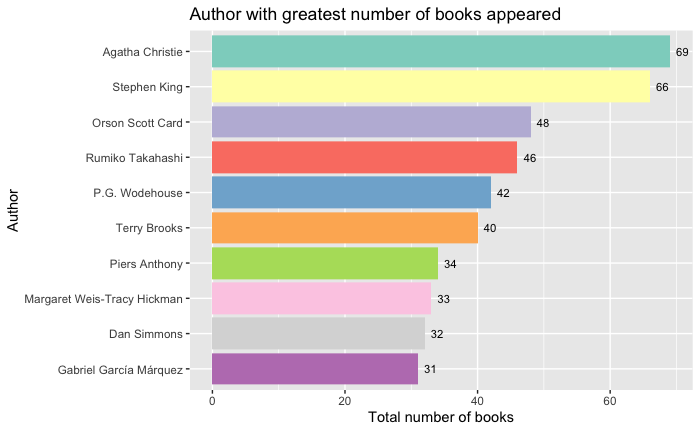

```r
author_most_books_top10 <- author_most_books[c(1:10),]
ggplot(data=author_most_books_top10, aes(x=reorder(author, total_number_of_books),y=total_number_of_books, fill = factor(c(1:nrow(author_most_books_top10))))) +
  theme(legend.position = "none") +
  geom_bar(stat="identity") +
  coord_flip() +
  scale_fill_brewer(palette="Set3") +
  ggtitle('Author with greatest number of books appeared') +
  labs(x = "Author", y = "Total number of books") +
  geom_text(
    aes(label = total_number_of_books), colour = "black",
    hjust = -0.5, size = 3,
    position = position_dodge(width = 1),
    inherit.aes = TRUE
  )
```

```r
author_most_books_top10
```

|  | author | total_number_of_books |
| --- | --- | --- |
| 51 | Agatha Christie | 69 |
| 6652 | Stephen King | 66 |
| 5422 | Orson Scott Card | 48 |
| 6283 | Rumiko Takahashi | 46 |
| 5462 | P.G. Wodehouse | 42 |
| 6897 | Terry Brooks | 40 |
| 5732 | Piers Anthony | 34 |
| 4614 | Margaret Weis-Tracy Hickman | 33 |
| 1297 | Dan Simmons | 32 |
| 2286 | Gabriel García Márquez | 31 |

Once again, the first two authors creates a huge gap with the remaining. Both Agatha Christie and Stephen King have more than 65 books, which is at least 18 books more than the third author, Orson Scott Card.

## What are the authors with the greatest number of highly-ranked books?

The definition of “highly-ranked books” in this context is relative. As such, we consider some of the following cases. We define a book to be highly-ranked if its average ranking is greater than: - 4.0 - 4.3 - 4.5

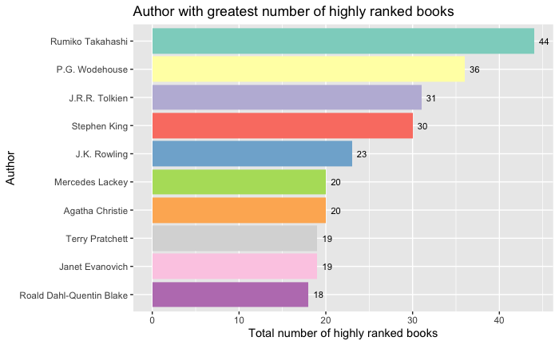

```r
author_most_book_high_ratings <- goodreads[goodreads$average_rating >= 4.0,]
author_most_books_high_ratings <- data.frame(table(author_most_book_high_ratings$authors), stringsAsFactors = FALSE)
names(author_most_books_high_ratings) <- c('author','number_of_books_>=_4.0')
author_most_books_high_ratings <- author_most_books_high_ratings[order(-author_most_books_high_ratings$`number_of_books_>=_4.0`),]
author_most_book_high_ratings_2 <- goodreads[goodreads$average_rating >= 4.3,]
author_most_books_high_ratings_2 <- data.frame(table(author_most_book_high_ratings_2$authors), stringsAsFactors = FALSE)
names(author_most_books_high_ratings_2) <- c('author','number_of_books_>=_4.3')
author_most_books_high_ratings_2 <- author_most_books_high_ratings_2[order(-author_most_books_high_ratings_2$`number_of_books_>=_4.3`),]
author_most_book_high_ratings_3 <- goodreads[goodreads$average_rating >= 4.5,]
author_most_books_high_ratings_3 <- data.frame(table(author_most_book_high_ratings_3$authors), stringsAsFactors = FALSE)
names(author_most_books_high_ratings_3) <- c('author','number_of_books_>=_4.5')
author_most_books_high_ratings_3 <- author_most_books_high_ratings_3[order(-author_most_books_high_ratings_3$`number_of_books_>=_4.5`),]
author_most_books_high_ratings_top10 <- author_most_books_high_ratings[c(1:10),]
ggplot(data=author_most_books_high_ratings_top10, aes(x=reorder(author, `number_of_books_>=_4.0`),y=`number_of_books_>=_4.0`, fill = factor(c(1:nrow(author_most_books_high_ratings_top10))))) +
  theme(legend.position = "none") +
  geom_bar(stat="identity") +
  coord_flip() +
  scale_fill_brewer(palette="Set3") +
  ggtitle('Author with greatest number of highly ranked books') +
  labs(x = "Author", y = "Total number of highly ranked books") +
  geom_text(
    aes(label = `number_of_books_>=_4.0`), colour = "black",
    hjust = -0.5, size = 3,
    position = position_dodge(width = 1),
    inherit.aes = TRUE
  )
```

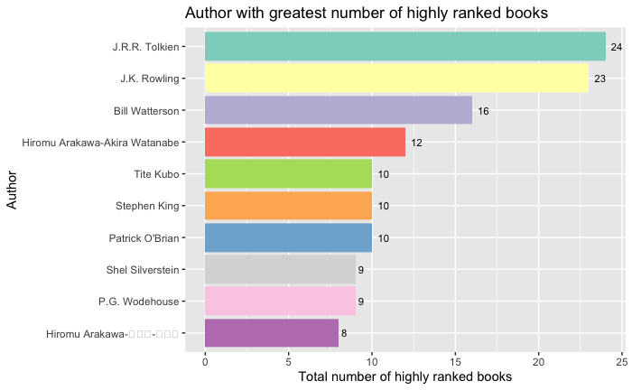

```r
author_most_books_high_ratings_top10_2 <- author_most_books_high_ratings_2[c(1:10),]
ggplot(data=author_most_books_high_ratings_top10_2, aes(x=reorder(author, `number_of_books_>=_4.3`),y=`number_of_books_>=_4.3`, fill = factor(c(1:nrow(author_most_books_high_ratings_top10_2))))) +
  theme(legend.position = "none") +
  geom_bar(stat="identity") +
  coord_flip() +
  scale_fill_brewer(palette="Set3") +
  ggtitle('Author with greatest number of highly ranked books') +
  labs(x = "Author", y = "Total number of highly ranked books") +
  geom_text(
    aes(label = `number_of_books_>=_4.3`), colour = "black",
    hjust = -0.5, size = 3,
    position = position_dodge(width = 1),
    inherit.aes = TRUE
  )
```

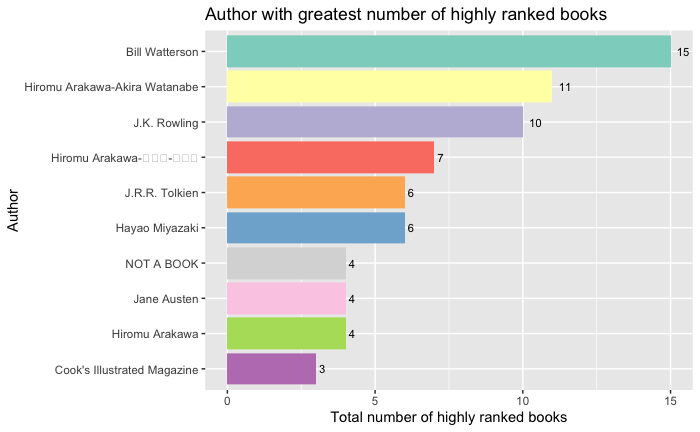

```r
author_most_books_high_ratings_top10_3 <- author_most_books_high_ratings_3[c(1:10),]
ggplot(data=author_most_books_high_ratings_top10_3, aes(x=reorder(author, `number_of_books_>=_4.5`),y=`number_of_books_>=_4.5`, fill = factor(c(1:nrow(author_most_books_high_ratings_top10_3))))) +
  theme(legend.position = "none") +
  geom_bar(stat="identity") +
  coord_flip() +
  scale_fill_brewer(palette="Set3") +
  ggtitle('Author with greatest number of highly ranked books') +
  labs(x = "Author", y = "Total number of highly ranked books") +
  geom_text(
    aes(label = `number_of_books_>=_4.5`), colour = "black",
    hjust = -0.5, size = 3,
    position = position_dodge(width = 1),
    inherit.aes = TRUE
  )
```

```r
x <- Reduce(function(x,y) merge(x,y,by="author",all=TRUE) ,list(author_most_books_high_ratings_top10,author_most_books_high_ratings_top10_2,author_most_books_high_ratings_top10_3))
x
```

| author | number_of_books_>=_4.0 | number_of_books_>=_4.3 | number_of_books_>=_4.5 |
| --- | --- | --- | --- |
| Agatha Christie | 20 | NA | NA |
| Bill Watterson | NA | 16 | 15 |
| Cook's Illustrated Magazine | NA | NA | 3 |
| Hayao Miyazaki | NA | NA | 6 |
| Hiromu Arakawa | NA | NA | 4 |
| Hiromu Arakawa-Akira Watanabe | NA | 12 | 11 |
| Hiromu Arakawa-荒川弘-方郁仁 | NA | 8 | 7 |
| J.K. Rowling | 23 | 23 | 10 |
| J.R.R. Tolkien | 31 | 24 | 6 |
| Jane Austen | NA | NA | 4 |

[output cut: 11 more lines]

# Applying K-means algorithm to cluster datasets

K-means clustering is the most commonly used unsupervised machine learning algorithm for partitioning a given data set into a set of k groups (i.e. k clusters), where k represents the number of groups pre-specified by the analyst.

First, we will build a model to cluster this dataset based on two variables: average_rating and ratings_count.

To determine the optimal number o clusters, we use the two following popular methods: - Elbow method - Sihouette method

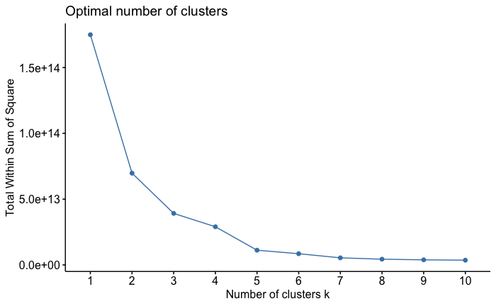

```r
goodreads_kmeans1 <- goodreads[,c('average_rating','ratings_count')]
set.seed(123)
fviz_nbclust(goodreads_kmeans1, kmeans, method = "wss")
```

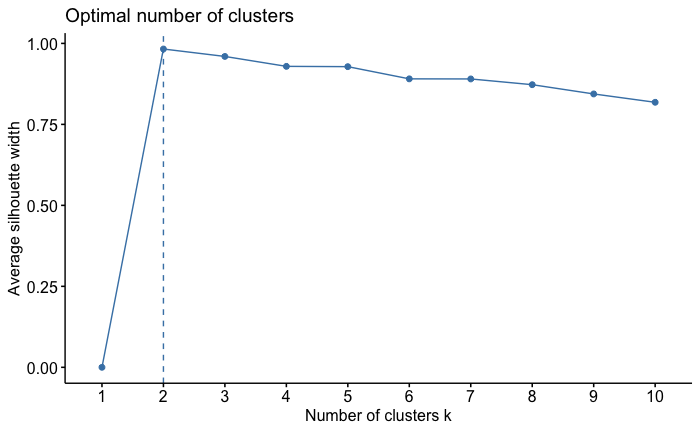

```r
fviz_nbclust(goodreads_kmeans1, kmeans, method = "silhouette")
```

```r
gap_stat_goodreads_kmeans1 <- clusGap(goodreads_kmeans1, FUN = kmeans, nstart = 25,
                    K.max = 10, B = 50)
```

[output not shown]

[output not shown]

[output not shown]

[output not shown]

[output not shown]

[output not shown]

[output not shown]

[output not shown]

[output not shown]

[output not shown]

[output not shown]

[output not shown]

[output not shown]

[output not shown]

[output not shown]

[output not shown]

[output not shown]

[output not shown]

[output not shown]

[output not shown]

[output not shown]

[output not shown]

[output not shown]

[output not shown]

[output not shown]

[output not shown]

[output not shown]

[output not shown]

[output not shown]

[output not shown]

[output not shown]

[output not shown]

[output not shown]

[output not shown]

[output not shown]

[output not shown]

[output not shown]

[output not shown]

[output not shown]

[output not shown]

[output not shown]

[output not shown]

[output not shown]

[output not shown]

[output not shown]

[output not shown]

[output not shown]

[output not shown]

[output not shown]

[output not shown]

[output not shown]

```r
set.seed(123)
final_kmeans1 <- kmeans(goodreads_kmeans1, 5, nstart = 25)
print(final_kmeans1)
```

[output not shown]

[output cut: 75 more lines]

```r
str(final_kmeans1)
```

```
List of 9
 $ cluster     : Named int [1:13714] 1 1 5 2 1 2 2 2 2 3 ...
  ..- attr(*, "names")= chr [1:13714] "1" "2" "3" "4" ...
 $ centers     : num [1:5, 1:2] 4.1 3.93 4.02 4.03 4.03 ...
  ..- attr(*, "dimnames")=List of 2
  .. ..$ : chr [1:5] "1" "2" "3" "4" ...
  .. ..$ : chr [1:2] "average_rating" "ratings_count"
 $ totss       : num 1.75e+14
 $ withinss    : num [1:5] 2.83e+12 2.39e+12 2.43e+12 2.75e+12 7.97e+11
 $ tot.withinss: num 1.12e+13
 $ betweenss   : num 1.64e+14
 $ size        : int [1:5] 23 13257 357 75 2
 $ iter        : int 6
 $ ifault      : int 0
 - attr(*, "class")= chr "kmeans"
```

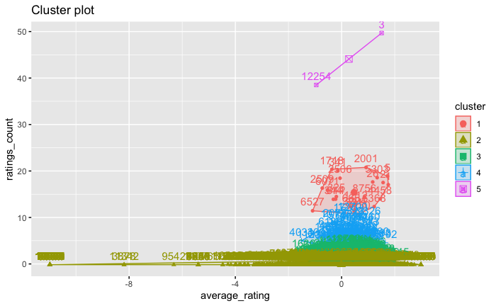

```r
fviz_cluster(final_kmeans1, data = goodreads_kmeans1)
```

We can see that the data are clearly classified into 5 different clusters. These clusters can be ordered by ratings count (i.e, the mean ratings count of these clusters can be ordered in a increasing order with clear differences).

As the rating count decreases, the average rating are more widely spread (i.e the average rating rate is higher), which means that the average rating is neither concentrated nor correct.

We also can extract the clusters and add to our initial data for futher analysis at the cluster level:

```r
goodreads_kmeans1_result <- goodreads %>%
                      mutate(Cluster = final_kmeans1$cluster)
goodreads_kmeans1_result
```

| bookID | title | authors | average_rating | isbn | isbn13 | language_code | num_pages | ratings_count | text_reviews_count | Cluster |
| --- | --- | --- | --- | --- | --- | --- | --- | --- | --- | --- |
| 1 | Harry Potter and the Half-Blood Prince (Harry Potter #6) | J.K. Rowling | 4.56 | 0439785960 | 9780439785969 | eng | 652 | 1944099 | 26249 | 1 |
| 2 | Harry Potter and the Order of the Phoenix (Harry Potter #5) | J.K. Rowling | 4.49 | 0439358078 | 9780439358071 | eng | 870 | 1996446 | 27613 | 1 |
| 3 | Harry Potter and the Sorcerer's Stone (Harry Potter #1) | J.K. Rowling | 4.47 | 0439554934 | 9780439554930 | eng | 320 | 5629932 | 70390 | 5 |
| 4 | Harry Potter and the Chamber of Secrets (Harry Potter #2) | J.K. Rowling | 4.41 | 0439554896 | 9780439554893 | eng | 352 | 6267 | 272 | 2 |
| 5 | Harry Potter and the Prisoner of Azkaban (Harry Potter #3) | J.K. Rowling | 4.55 | 043965548X | 9780439655484 | eng | 435 | 2149872 | 33964 | 1 |
| 8 | Harry Potter Boxed Set Books 1-5 (Harry Potter #1-5) | J.K. Rowling | 4.78 | 0439682584 | 9780439682589 | eng | 2690 | 38872 | 154 | 2 |
| 9 | Unauthorized Harry Potter Book Seven News: Half-Blood Prince Analysis and Speculation | W. Frederick Zimmerman | 3.69 | 0976540606 | 9780976540601 | en-US | 152 | 18 | 1 | 2 |
| 10 | Harry Potter Collection (Harry Potter #1-6) | J.K. Rowling | 4.73 | 0439827604 | 9780439827607 | eng | 3342 | 27410 | 820 | 2 |
| 12 | The Ultimate Hitchhiker's Guide: Five Complete Novels and One Story (Hitchhiker's Guide to the Galaxy #1-5) | Douglas Adams | 4.38 | 0517226952 | 9780517226957 | eng | 815 | 3602 | 258 | 2 |
| 13 | The Ultimate Hitchhiker's Guide to the Galaxy | Douglas Adams | 4.38 | 0345453743 | 9780345453747 | eng | 815 | 240189 | 3954 | 3 |

[output cut: 990 more lines]

There is a problem emerging from the model above. As the ratings count is significantly larger than the average rating, this model seems to be in favor of ratings count, which may lead to bias. As a result, we will normalize the two variables and re-build this algorithm.